# Analyzing Data As A Data Scientist & The Body Fat Dataset

This lecture will walk through the body fat data set as a data scientist.

Hopefully, this lecture will give a sense of how you, as a data scientist, should approach analyzing data, regardless of the type of analysis you are planning to run.

```r
#This is some wrapper code for Juypter Notebook (ignore it)
options(repr.plot.width=10, repr.plot.height=10)
options(repr.matrix.max.rows=20, repr.matrix.max.cols=20)
```

## Body Fat Data

The goal of the project is to come up with a **simple** and **accurate** way of deteriming body fat percentage of males based on readily available clinical measurements.

The data set contains measurements from 252 men who had their body fat percentage accurately measured via underwater weighing.

1. The outcome variable is body fat percentage
2. The set of predictors are every variable except ID number, body fat percentage, and density. In particular, density is not a predictor because body fat was directly calculated based on density (see data description of project 1) and practically speaking, density is not a readily available clinical measurement compared to other predictors in the dataset.

```r
BodyFat = read.csv("BodyFat.csv") #Read data into R
attach(BodyFat) # This "attaches" the data into R.
dim(BodyFat) # Dimension of the data (number of rows, number of columns)
```

1. 252

2. 17

```r
colnames(BodyFat) #Variables in the Data
```

1. 'IDNO'

2. 'BODYFAT'

3. 'DENSITY'

4. 'AGE'

5. 'WEIGHT'

6. 'HEIGHT'

7. 'ADIPOSITY'

8. 'NECK'

9. 'CHEST'

10. 'ABDOMEN'

11. 'HIP'

12. 'THIGH'

13. 'KNEE'

14. 'ANKLE'

15. 'BICEPS'

16. 'FOREARM'

17. 'WRIST'

## Step 1: Analyzing Raw Data

What I typically do first is to look at the raw data to see if there is anything interesting (e.g. precision, units of measurement, outliers, general patterns, etc.)

I also read about any background information related to the data.

*Tangent (for your data science career)*: If the data is too large (i.e. say a million data points), I simply take multiple, small random subset of the original data and examine these subsets.

```r
head(BodyFat) #Look at the first few data points
tail(BodyFat) #Look at the last few data points
```

A data.frame: 6 × 17

|  | IDNO <int> | BODYFAT <dbl> | DENSITY <dbl> | AGE <int> | WEIGHT <dbl> | HEIGHT <dbl> | ADIPOSITY <dbl> | NECK <dbl> | CHEST <dbl> | ABDOMEN <dbl> | HIP <dbl> | THIGH <dbl> | KNEE <dbl> | ANKLE <dbl> | BICEPS <dbl> | FOREARM <dbl> | WRIST <dbl> |
| --- | --- | --- | --- | --- | --- | --- | --- | --- | --- | --- | --- | --- | --- | --- | --- | --- | --- |
| 1 | 1 | 12.6 | 1.0708 | 23 | 154.25 | 67.75 | 23.7 | 36.2 | 93.1 | 85.2 | 94.5 | 59.0 | 37.3 | 21.9 | 32.0 | 27.4 | 17.1 |
| 2 | 2 | 6.9 | 1.0853 | 22 | 173.25 | 72.25 | 23.4 | 38.5 | 93.6 | 83.0 | 98.7 | 58.7 | 37.3 | 23.4 | 30.5 | 28.9 | 18.2 |
| 3 | 3 | 24.6 | 1.0414 | 22 | 154.00 | 66.25 | 24.7 | 34.0 | 95.8 | 87.9 | 99.2 | 59.6 | 38.9 | 24.0 | 28.8 | 25.2 | 16.6 |
| 4 | 4 | 10.9 | 1.0751 | 26 | 184.75 | 72.25 | 24.9 | 37.4 | 101.8 | 86.4 | 101.2 | 60.1 | 37.3 | 22.8 | 32.4 | 29.4 | 18.2 |
| 5 | 5 | 27.8 | 1.0340 | 24 | 184.25 | 71.25 | 25.6 | 34.4 | 97.3 | 100.0 | 101.9 | 63.2 | 42.2 | 24.0 | 32.2 | 27.7 | 17.7 |
| 6 | 6 | 20.6 | 1.0502 | 24 | 210.25 | 74.75 | 26.5 | 39.0 | 104.5 | 94.4 | 107.8 | 66.0 | 42.0 | 25.6 | 35.7 | 30.6 | 18.8 |

A data.frame: 6 × 17

|  | IDNO <int> | BODYFAT <dbl> | DENSITY <dbl> | AGE <int> | WEIGHT <dbl> | HEIGHT <dbl> | ADIPOSITY <dbl> | NECK <dbl> | CHEST <dbl> | ABDOMEN <dbl> | HIP <dbl> | THIGH <dbl> | KNEE <dbl> | ANKLE <dbl> | BICEPS <dbl> | FOREARM <dbl> | WRIST <dbl> |
| --- | --- | --- | --- | --- | --- | --- | --- | --- | --- | --- | --- | --- | --- | --- | --- | --- | --- |
| 247 | 247 | 29.1 | 1.0308 | 69 | 215.50 | 70.50 | 30.5 | 40.8 | 113.7 | 107.6 | 110.0 | 63.3 | 44.0 | 22.6 | 37.5 | 32.6 | 18.8 |
| 248 | 248 | 11.5 | 1.0736 | 70 | 134.25 | 67.00 | 21.1 | 34.9 | 89.2 | 83.6 | 88.8 | 49.6 | 34.8 | 21.5 | 25.6 | 25.7 | 18.5 |
| 249 | 249 | 32.3 | 1.0236 | 72 | 201.00 | 69.75 | 29.1 | 40.9 | 108.5 | 105.0 | 104.5 | 59.6 | 40.8 | 23.2 | 35.2 | 28.6 | 20.1 |
| 250 | 250 | 28.3 | 1.0328 | 72 | 186.75 | 66.00 | 30.2 | 38.9 | 111.1 | 111.5 | 101.7 | 60.3 | 37.3 | 21.5 | 31.3 | 27.2 | 18.0 |
| 251 | 251 | 25.3 | 1.0399 | 72 | 190.75 | 70.50 | 27.0 | 38.9 | 108.3 | 101.3 | 97.8 | 56.0 | 41.6 | 22.7 | 30.5 | 29.4 | 19.8 |
| 252 | 252 | 30.7 | 1.0271 | 74 | 207.50 | 70.00 | 29.8 | 40.8 | 112.4 | 108.5 | 107.1 | 59.3 | 42.2 | 24.6 | 33.7 | 30.0 | 20.9 |

```r
summary(BodyFat) #Gives you a brief summary statistic of all the variables in the data
# Note that the first column contains the index number of each individual.
```

```
      IDNO           BODYFAT         DENSITY           AGE
 Min.   :  1.00   Min.   : 0.00   Min.   :0.995   Min.   :22.00
 1st Qu.: 63.75   1st Qu.:12.80   1st Qu.:1.041   1st Qu.:35.75
 Median :126.50   Median :19.00   Median :1.055   Median :43.00
 Mean   :126.50   Mean   :18.94   Mean   :1.056   Mean   :44.88
 3rd Qu.:189.25   3rd Qu.:24.60   3rd Qu.:1.070   3rd Qu.:54.00
 Max.   :252.00   Max.   :45.10   Max.   :1.109   Max.   :81.00
     WEIGHT          HEIGHT        ADIPOSITY          NECK
 Min.   :118.5   Min.   :29.50   Min.   :18.10   Min.   :31.10
 1st Qu.:159.0   1st Qu.:68.25   1st Qu.:23.10   1st Qu.:36.40
 Median :176.5   Median :70.00   Median :25.05   Median :38.00
 Mean   :178.9   Mean   :70.15   Mean   :25.44   Mean   :37.99
 3rd Qu.:197.0   3rd Qu.:72.25   3rd Qu.:27.32   3rd Qu.:39.42
 Max.   :363.1   Max.   :77.75   Max.   :48.90   Max.   :51.20
     CHEST           ABDOMEN            HIP            THIGH
 Min.   : 79.30   Min.   : 69.40   Min.   : 85.0   Min.   :47.20
 1st Qu.: 94.35   1st Qu.: 84.58   1st Qu.: 95.5   1st Qu.:56.00
 Median : 99.65   Median : 90.95   Median : 99.3   Median :59.00
 Mean   :100.82   Mean   : 92.56   Mean   : 99.9   Mean   :59.41
 3rd Qu.:105.38   3rd Qu.: 99.33   3rd Qu.:103.5   3rd Qu.:62.35
 Max.   :136.20   Max.   :148.10   Max.   :147.7   Max.   :87.30
      KNEE           ANKLE          BICEPS         FOREARM          WRIST
 Min.   :33.00   Min.   :19.1   Min.   :24.80   Min.   :21.00   Min.   :15.80
 1st Qu.:36.98   1st Qu.:22.0   1st Qu.:30.20   1st Qu.:27.30   1st Qu.:17.60
 Median :38.50   Median :22.8   Median :32.05   Median :28.70   Median :18.30
 Mean   :38.59   Mean   :23.1   Mean   :32.27   Mean   :28.66   Mean   :18.23
 3rd Qu.:39.92   3rd Qu.:24.0   3rd Qu.:34.33   3rd Qu.:30.00   3rd Qu.:18.80
 Max.   :49.10   Max.   :33.9   Max.   :45.00   Max.   :34.90   Max.   :21.40
```

There are many ways to look at the raw data. I'm not going to go over all of them, but some of the most common ones are listed below.

```r
#Looks at the first row of the data
BodyFat[1,]

#Looks at the first 10 rows of the data
BodyFat[1:10,]

#Looks at the 20th, 27th, and 39th individual in the data
BodyFat[c(20,27,39),]
```

A data.frame: 1 × 17

|  | IDNO <int> | BODYFAT <dbl> | DENSITY <dbl> | AGE <int> | WEIGHT <dbl> | HEIGHT <dbl> | ADIPOSITY <dbl> | NECK <dbl> | CHEST <dbl> | ABDOMEN <dbl> | HIP <dbl> | THIGH <dbl> | KNEE <dbl> | ANKLE <dbl> | BICEPS <dbl> | FOREARM <dbl> | WRIST <dbl> |
| --- | --- | --- | --- | --- | --- | --- | --- | --- | --- | --- | --- | --- | --- | --- | --- | --- | --- |
| 1 | 1 | 12.6 | 1.0708 | 23 | 154.25 | 67.75 | 23.7 | 36.2 | 93.1 | 85.2 | 94.5 | 59 | 37.3 | 21.9 | 32 | 27.4 | 17.1 |

A data.frame: 10 × 17

|  | IDNO <int> | BODYFAT <dbl> | DENSITY <dbl> | AGE <int> | WEIGHT <dbl> | HEIGHT <dbl> | ADIPOSITY <dbl> | NECK <dbl> | CHEST <dbl> | ABDOMEN <dbl> | HIP <dbl> | THIGH <dbl> | KNEE <dbl> | ANKLE <dbl> | BICEPS <dbl> | FOREARM <dbl> | WRIST <dbl> |
| --- | --- | --- | --- | --- | --- | --- | --- | --- | --- | --- | --- | --- | --- | --- | --- | --- | --- |
| 1 | 1 | 12.6 | 1.0708 | 23 | 154.25 | 67.75 | 23.7 | 36.2 | 93.1 | 85.2 | 94.5 | 59.0 | 37.3 | 21.9 | 32.0 | 27.4 | 17.1 |
| 2 | 2 | 6.9 | 1.0853 | 22 | 173.25 | 72.25 | 23.4 | 38.5 | 93.6 | 83.0 | 98.7 | 58.7 | 37.3 | 23.4 | 30.5 | 28.9 | 18.2 |
| 3 | 3 | 24.6 | 1.0414 | 22 | 154.00 | 66.25 | 24.7 | 34.0 | 95.8 | 87.9 | 99.2 | 59.6 | 38.9 | 24.0 | 28.8 | 25.2 | 16.6 |
| 4 | 4 | 10.9 | 1.0751 | 26 | 184.75 | 72.25 | 24.9 | 37.4 | 101.8 | 86.4 | 101.2 | 60.1 | 37.3 | 22.8 | 32.4 | 29.4 | 18.2 |
| 5 | 5 | 27.8 | 1.0340 | 24 | 184.25 | 71.25 | 25.6 | 34.4 | 97.3 | 100.0 | 101.9 | 63.2 | 42.2 | 24.0 | 32.2 | 27.7 | 17.7 |
| 6 | 6 | 20.6 | 1.0502 | 24 | 210.25 | 74.75 | 26.5 | 39.0 | 104.5 | 94.4 | 107.8 | 66.0 | 42.0 | 25.6 | 35.7 | 30.6 | 18.8 |
| 7 | 7 | 19.0 | 1.0549 | 26 | 181.00 | 69.75 | 26.2 | 36.4 | 105.1 | 90.7 | 100.3 | 58.4 | 38.3 | 22.9 | 31.9 | 27.8 | 17.7 |
| 8 | 8 | 12.8 | 1.0704 | 25 | 176.00 | 72.50 | 23.6 | 37.8 | 99.6 | 88.5 | 97.1 | 60.0 | 39.4 | 23.2 | 30.5 | 29.0 | 18.8 |
| 9 | 9 | 5.1 | 1.0900 | 25 | 191.00 | 74.00 | 24.6 | 38.1 | 100.9 | 82.5 | 99.9 | 62.9 | 38.3 | 23.8 | 35.9 | 31.1 | 18.2 |
| 10 | 10 | 12.0 | 1.0722 | 23 | 198.25 | 73.50 | 25.8 | 42.1 | 99.6 | 88.6 | 104.1 | 63.1 | 41.7 | 25.0 | 35.6 | 30.0 | 19.2 |

A data.frame: 3 × 17

|  | IDNO <int> | BODYFAT <dbl> | DENSITY <dbl> | AGE <int> | WEIGHT <dbl> | HEIGHT <dbl> | ADIPOSITY <dbl> | NECK <dbl> | CHEST <dbl> | ABDOMEN <dbl> | HIP <dbl> | THIGH <dbl> | KNEE <dbl> | ANKLE <dbl> | BICEPS <dbl> | FOREARM <dbl> | WRIST <dbl> |
| --- | --- | --- | --- | --- | --- | --- | --- | --- | --- | --- | --- | --- | --- | --- | --- | --- | --- |
| 20 | 20 | 16.5 | 1.0610 | 33 | 211.75 | 73.50 | 27.6 | 40.0 | 106.2 | 100.5 | 109.0 | 65.8 | 40.6 | 24.0 | 37.1 | 30.1 | 18.2 |
| 27 | 27 | 8.5 | 1.0811 | 34 | 131.50 | 67.50 | 20.3 | 36.2 | 88.6 | 74.6 | 85.3 | 51.7 | 34.7 | 21.4 | 28.7 | 27.0 | 16.5 |
| 39 | 39 | 33.8 | 1.0202 | 46 | 363.15 | 72.25 | 48.9 | 51.2 | 136.2 | 148.1 | 147.7 | 87.3 | 49.1 | 29.6 | 45.0 | 29.0 | 21.4 |

```r
#Looks only at the first five columns of the data
BodyFat[,1:5]

#Looks at the 3rd, 10th, and 13th columns of the data
BodyFat[,c(3,10,13)]

#Looks only at the columns with names BODYFAT, AGE, WEIGHT, and CHEST
BodyFat[,c("BODYFAT","AGE","WEIGHT","CHEST")]
```

A data.frame: 252 × 5

| IDNO <int> | BODYFAT <dbl> | DENSITY <dbl> | AGE <int> | WEIGHT <dbl> |
| --- | --- | --- | --- | --- |
| 1 | 12.6 | 1.0708 | 23 | 154.25 |
| 2 | 6.9 | 1.0853 | 22 | 173.25 |
| 3 | 24.6 | 1.0414 | 22 | 154.00 |
| 4 | 10.9 | 1.0751 | 26 | 184.75 |
| 5 | 27.8 | 1.0340 | 24 | 184.25 |
| 6 | 20.6 | 1.0502 | 24 | 210.25 |
| 7 | 19.0 | 1.0549 | 26 | 181.00 |
| 8 | 12.8 | 1.0704 | 25 | 176.00 |
| 9 | 5.1 | 1.0900 | 25 | 191.00 |
| 10 | 12.0 | 1.0722 | 23 | 198.25 |
| ⋮ | ⋮ | ⋮ | ⋮ | ⋮ |
| 243 | 29.3 | 1.0304 | 66 | 234.25 |
| 244 | 31.4 | 1.0256 | 67 | 227.75 |
| 245 | 28.1 | 1.0334 | 67 | 199.50 |
| 246 | 15.3 | 1.0641 | 68 | 155.50 |
| 247 | 29.1 | 1.0308 | 69 | 215.50 |
| 248 | 11.5 | 1.0736 | 70 | 134.25 |
| 249 | 32.3 | 1.0236 | 72 | 201.00 |
| 250 | 28.3 | 1.0328 | 72 | 186.75 |
| 251 | 25.3 | 1.0399 | 72 | 190.75 |
| 252 | 30.7 | 1.0271 | 74 | 207.50 |

A data.frame: 252 × 3

| DENSITY <dbl> | ABDOMEN <dbl> | KNEE <dbl> |
| --- | --- | --- |
| 1.0708 | 85.2 | 37.3 |
| 1.0853 | 83.0 | 37.3 |
| 1.0414 | 87.9 | 38.9 |
| 1.0751 | 86.4 | 37.3 |
| 1.0340 | 100.0 | 42.2 |
| 1.0502 | 94.4 | 42.0 |
| 1.0549 | 90.7 | 38.3 |
| 1.0704 | 88.5 | 39.4 |
| 1.0900 | 82.5 | 38.3 |
| 1.0722 | 88.6 | 41.7 |
| ⋮ | ⋮ | ⋮ |
| 1.0304 | 109.0 | 42.4 |
| 1.0256 | 113.4 | 46.0 |
| 1.0334 | 106.1 | 38.8 |
| 1.0641 | 84.3 | 37.5 |
| 1.0308 | 107.6 | 44.0 |
| 1.0736 | 83.6 | 34.8 |
| 1.0236 | 105.0 | 40.8 |
| 1.0328 | 111.5 | 37.3 |
| 1.0399 | 101.3 | 41.6 |
| 1.0271 | 108.5 | 42.2 |

A data.frame: 252 × 4

| BODYFAT <dbl> | AGE <int> | WEIGHT <dbl> | CHEST <dbl> |
| --- | --- | --- | --- |
| 12.6 | 23 | 154.25 | 93.1 |
| 6.9 | 22 | 173.25 | 93.6 |
| 24.6 | 22 | 154.00 | 95.8 |
| 10.9 | 26 | 184.75 | 101.8 |
| 27.8 | 24 | 184.25 | 97.3 |
| 20.6 | 24 | 210.25 | 104.5 |
| 19.0 | 26 | 181.00 | 105.1 |
| 12.8 | 25 | 176.00 | 99.6 |
| 5.1 | 25 | 191.00 | 100.9 |
| 12.0 | 23 | 198.25 | 99.6 |
| ⋮ | ⋮ | ⋮ | ⋮ |
| 29.3 | 66 | 234.25 | 119.7 |
| 31.4 | 67 | 227.75 | 115.8 |
| 28.1 | 67 | 199.50 | 118.3 |
| 15.3 | 68 | 155.50 | 97.4 |
| 29.1 | 69 | 215.50 | 113.7 |
| 11.5 | 70 | 134.25 | 89.2 |
| 32.3 | 72 | 201.00 | 108.5 |
| 28.3 | 72 | 186.75 | 111.1 |
| 25.3 | 72 | 190.75 | 108.3 |
| 30.7 | 74 | 207.50 | 112.4 |

```r
# You can combine row and column indexing to get specific subsets of the whole data.
BodyFat[1:10,c("BODYFAT","AGE","WEIGHT")]

# Of course, you can store all these subsetted data with a new variable name
subsetOfBodyFat = BodyFat[1:10,c("BODYFAT","AGE","WEIGHT")]
```

A data.frame: 10 × 3

|  | BODYFAT <dbl> | AGE <int> | WEIGHT <dbl> |
| --- | --- | --- | --- |
| 1 | 12.6 | 23 | 154.25 |
| 2 | 6.9 | 22 | 173.25 |
| 3 | 24.6 | 22 | 154.00 |
| 4 | 10.9 | 26 | 184.75 |
| 5 | 27.8 | 24 | 184.25 |
| 6 | 20.6 | 24 | 210.25 |
| 7 | 19.0 | 26 | 181.00 |
| 8 | 12.8 | 25 | 176.00 |
| 9 | 5.1 | 25 | 191.00 |
| 10 | 12.0 | 23 | 198.25 |

Some "background reading"...

[figure not shown]

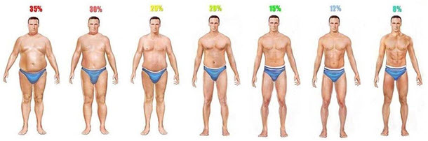

Barreira et al. (2011) "Body Adiposity Index, Body Mass Index and Body Fat in White and Black Adults." JAMA.

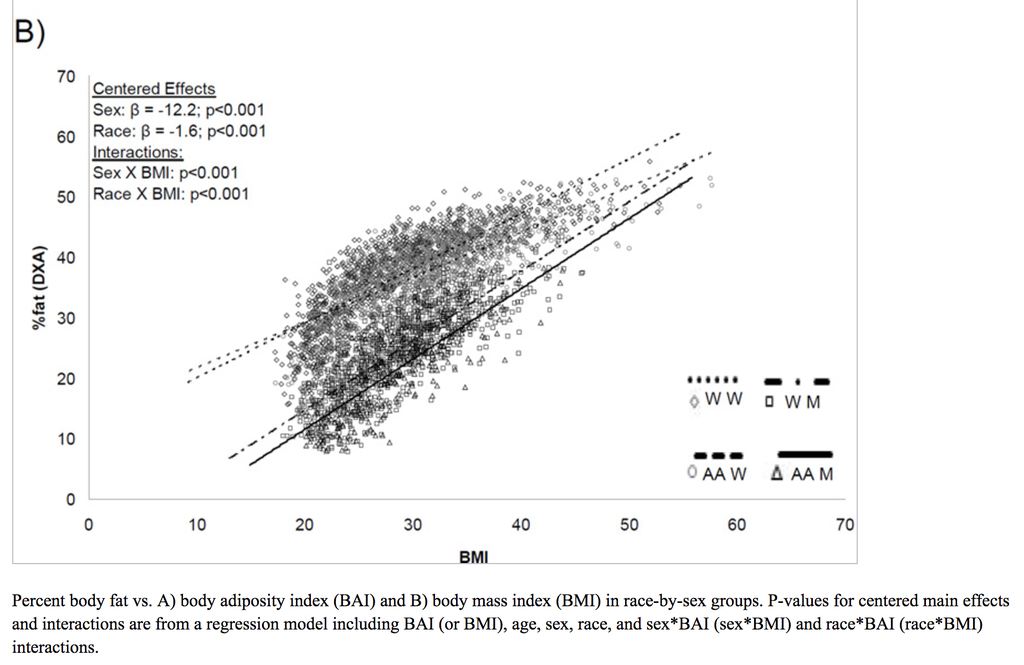

## Step 2: Visualizing Data

Next, I start looking for the "big picture" by visualizing the data with histograms, scatterplots, and/or boxplots.

Let's start with histograms. The first plot shows one single histogram of body fat percentage.

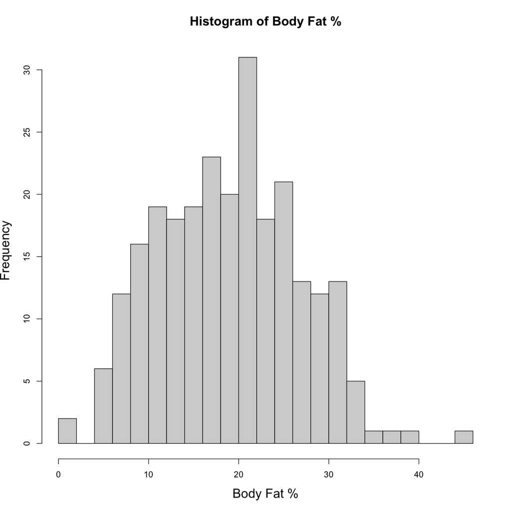

```r
# breaks option inside hist() controls the resolution of the histogram.
# High breaks number indicates higher resolution while small breaks number indicates low resolution.
# Play around with the breaks!

# cex controls the size of different elements of the plot. cex.lab controls the x and y axis labels,
# cex.main controls the title of the plot. cex as is controls the size of the points usually in a scatterplot.
hist(BODYFAT,breaks=30,cex.lab=1.5,cex.main=1.5,
     main="Histogram of Body Fat %",xlab="Body Fat %")
```

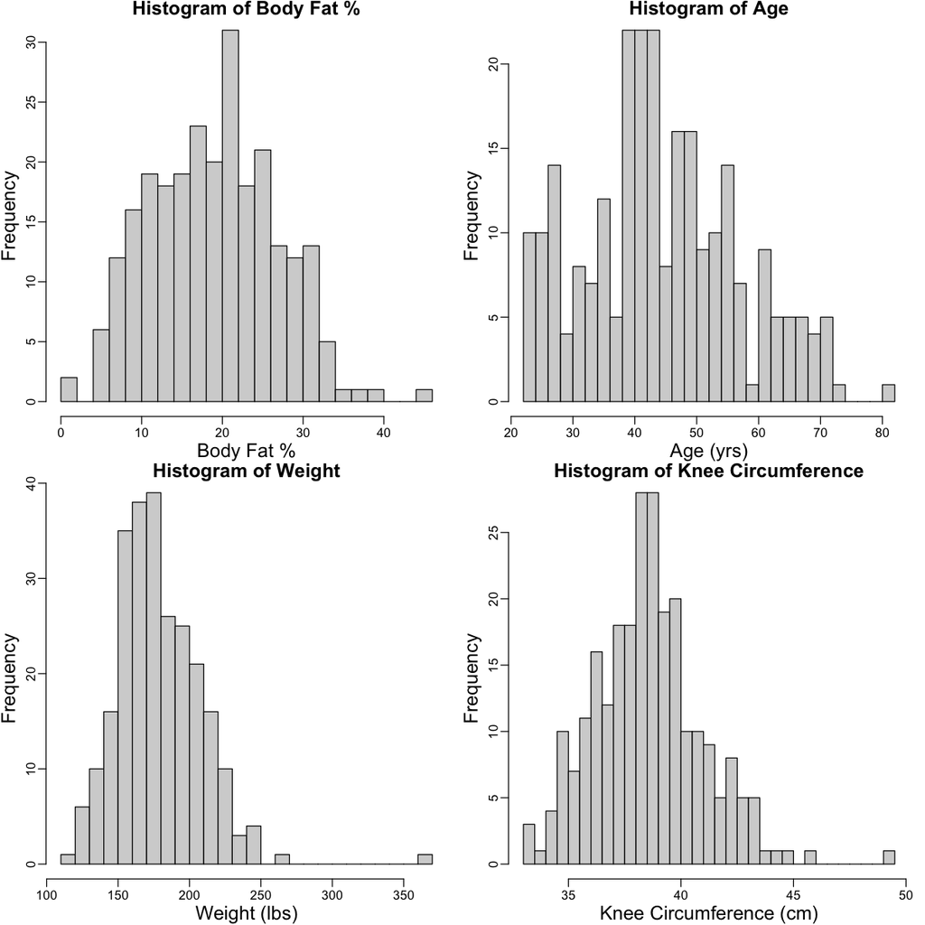

```r
# You can also create multiple plots in the same window using the mfrow option inside the par() function
par(mfrow=c(2,2)) #Makes a two-by-two, i.e. (2,2), plotting window
par(mgp=c(1.8,.5,0), mar=c(3,3,1,1)) #"Beautifies" plots when creating multiple figures. Google this for more info.

hist(BODYFAT,breaks=30,cex.lab=1.5,cex.main=1.5,
     main="Histogram of Body Fat %",xlab="Body Fat %")
hist(AGE,breaks=30,cex.lab=1.5,cex.main=1.5,
     main="Histogram of Age",xlab="Age (yrs)")
hist(WEIGHT,breaks=30,cex.lab=1.5,cex.main=1.5,
     main="Histogram of Weight",xlab="Weight (lbs)")
hist(KNEE,breaks=30,cex.lab=1.5,cex.main=1.5,
     main="Histogram of Knee Circumference",xlab="Knee Circumference (cm)")
```

It seems like majority of individuals weight around 175 lbs

Based on the histograms, I sometimes look at subsets of the data.

These help me detect outliers or notice general patterns about the measurements.

*Tangent (for your data science career)*: Many companies typically use `SQL` (database language), `Python` (general-purpose language), and `R` (scientific language). Also, when using `R`, industry typically uses the packages `dplyr` or `data.table` for data manipulation (i.e. merge,subset, summary statistics, etc.).

Here are some "subsetting" operations you can do on the dataset to help better understand different parts of the dataset.

```r
#Subset of the data whose weight is greater than 350 pounds
BodyFat[WEIGHT > 350,]
```

A data.frame: 1 × 17

|  | IDNO <int> | BODYFAT <dbl> | DENSITY <dbl> | AGE <int> | WEIGHT <dbl> | HEIGHT <dbl> | ADIPOSITY <dbl> | NECK <dbl> | CHEST <dbl> | ABDOMEN <dbl> | HIP <dbl> | THIGH <dbl> | KNEE <dbl> | ANKLE <dbl> | BICEPS <dbl> | FOREARM <dbl> | WRIST <dbl> |
| --- | --- | --- | --- | --- | --- | --- | --- | --- | --- | --- | --- | --- | --- | --- | --- | --- | --- |
| 39 | 39 | 33.8 | 1.0202 | 46 | 363.15 | 72.25 | 48.9 | 51.2 | 136.2 | 148.1 | 147.7 | 87.3 | 49.1 | 29.6 | 45 | 29 | 21.4 |

```r
# Subset of the data whose weight is less than 150 AND taller than 6ft (72 inches) (i.e. skinny, tall people)
# The & operator inside the expression acts as the AND command
BodyFat[WEIGHT < 150 & HEIGHT >= 72,]
```

A data.frame: 2 × 17

|  | IDNO <int> | BODYFAT <dbl> | DENSITY <dbl> | AGE <int> | WEIGHT <dbl> | HEIGHT <dbl> | ADIPOSITY <dbl> | NECK <dbl> | CHEST <dbl> | ABDOMEN <dbl> | HIP <dbl> | THIGH <dbl> | KNEE <dbl> | ANKLE <dbl> | BICEPS <dbl> | FOREARM <dbl> | WRIST <dbl> |
| --- | --- | --- | --- | --- | --- | --- | --- | --- | --- | --- | --- | --- | --- | --- | --- | --- | --- |
| 149 | 149 | 6.1 | 1.0873 | 25 | 143.75 | 72.50 | 19.3 | 35.2 | 92.3 | 76.5 | 92.1 | 51.9 | 35.7 | 22.0 | 25.8 | 25.2 | 16.9 |
| 153 | 153 | 10.6 | 1.0758 | 27 | 146.00 | 72.25 | 19.7 | 34.1 | 88.5 | 72.8 | 91.1 | 53.6 | 36.8 | 23.8 | 27.8 | 26.3 | 17.4 |

```r
# Subset of the data whose weight is greater than 225 pounds taller OR is younger than 25.
# The | operator inside the expression acts as the OR command
BodyFat[WEIGHT > 250 | AGE < 25,]
```

A data.frame: 12 × 17

|  | IDNO <int> | BODYFAT <dbl> | DENSITY <dbl> | AGE <int> | WEIGHT <dbl> | HEIGHT <dbl> | ADIPOSITY <dbl> | NECK <dbl> | CHEST <dbl> | ABDOMEN <dbl> | HIP <dbl> | THIGH <dbl> | KNEE <dbl> | ANKLE <dbl> | BICEPS <dbl> | FOREARM <dbl> | WRIST <dbl> |
| --- | --- | --- | --- | --- | --- | --- | --- | --- | --- | --- | --- | --- | --- | --- | --- | --- | --- |
| 1 | 1 | 12.6 | 1.0708 | 23 | 154.25 | 67.75 | 23.7 | 36.2 | 93.1 | 85.2 | 94.5 | 59.0 | 37.3 | 21.9 | 32.0 | 27.4 | 17.1 |
| 2 | 2 | 6.9 | 1.0853 | 22 | 173.25 | 72.25 | 23.4 | 38.5 | 93.6 | 83.0 | 98.7 | 58.7 | 37.3 | 23.4 | 30.5 | 28.9 | 18.2 |
| 3 | 3 | 24.6 | 1.0414 | 22 | 154.00 | 66.25 | 24.7 | 34.0 | 95.8 | 87.9 | 99.2 | 59.6 | 38.9 | 24.0 | 28.8 | 25.2 | 16.6 |
| 5 | 5 | 27.8 | 1.0340 | 24 | 184.25 | 71.25 | 25.6 | 34.4 | 97.3 | 100.0 | 101.9 | 63.2 | 42.2 | 24.0 | 32.2 | 27.7 | 17.7 |
| 6 | 6 | 20.6 | 1.0502 | 24 | 210.25 | 74.75 | 26.5 | 39.0 | 104.5 | 94.4 | 107.8 | 66.0 | 42.0 | 25.6 | 35.7 | 30.6 | 18.8 |
| 10 | 10 | 12.0 | 1.0722 | 23 | 198.25 | 73.50 | 25.8 | 42.1 | 99.6 | 88.6 | 104.1 | 63.1 | 41.7 | 25.0 | 35.6 | 30.0 | 19.2 |
| 39 | 39 | 33.8 | 1.0202 | 46 | 363.15 | 72.25 | 48.9 | 51.2 | 136.2 | 148.1 | 147.7 | 87.3 | 49.1 | 29.6 | 45.0 | 29.0 | 21.4 |
| 41 | 41 | 33.1 | 1.0217 | 45 | 262.75 | 68.75 | 39.1 | 43.2 | 128.3 | 126.2 | 125.6 | 72.5 | 39.6 | 26.6 | 36.4 | 32.7 | 21.4 |
| 144 | 144 | 9.9 | 1.0775 | 23 | 159.75 | 72.25 | 21.6 | 35.5 | 92.1 | 77.1 | 93.9 | 56.1 | 36.1 | 22.7 | 30.5 | 27.2 | 18.2 |
| 145 | 145 | 10.8 | 1.0754 | 23 | 188.15 | 77.50 | 22.1 | 38.0 | 96.6 | 85.3 | 102.5 | 59.1 | 37.6 | 23.2 | 31.8 | 29.7 | 18.3 |
| 146 | 146 | 14.4 | 1.0664 | 24 | 156.00 | 70.75 | 21.9 | 35.7 | 92.7 | 81.9 | 95.3 | 56.4 | 36.5 | 22.0 | 33.5 | 28.3 | 17.3 |
| 147 | 147 | 19.0 | 1.0550 | 24 | 208.50 | 72.75 | 27.7 | 39.2 | 102.0 | 99.1 | 110.1 | 71.2 | 43.5 | 25.2 | 36.1 | 30.3 | 18.7 |

There are lots of things you can do with plotting and subsetting.

In my opinion, the first two steps help me get a better picture of the data, specifically

1. How to clean up data (i.e. are some measurements incorrect? )
2. How measurements are taken (e.g. units, precision, etc.)
3. Any odd individuals in the data?
4. General demographic information (e.g. age group, height range, etc.)

*Tangent (for your data science career)*: In real life, you'll spend A LOT of time doing these two steps. Personally, I spend about 70% of my time doing this. If you have a better idea of your data and can clean it at this stage of your data analysis (leaving proper documentation on how you cleaned it), subsequent statistical analysis becomes much easier.

## Step 3: Statistical Modeling and Analysis

After the first two steps, I try to decide on what type of statistical analysis I want to use.

For this lecture only, we'll look at the relationship between body fat % and age.

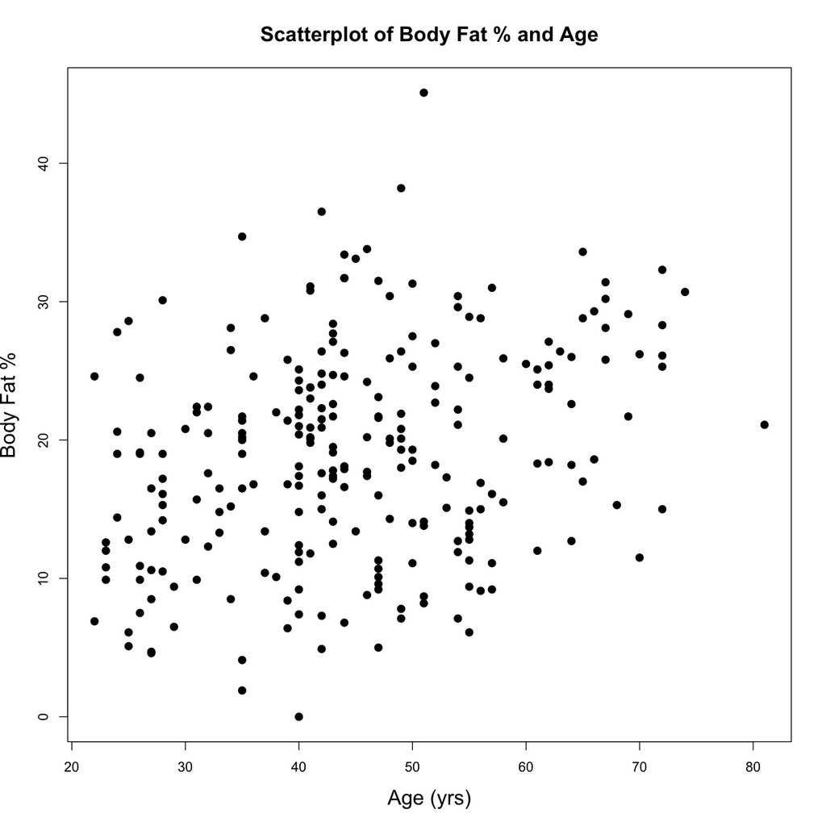

```r
# cex as is controls the size of the points
plot(AGE,BODYFAT,pch=19,cex=1.2,cex.lab=1.5,cex.main=1.5,
     xlab="Age (yrs)",ylab="Body Fat %",main="Scatterplot of Body Fat % and Age")
```

What do you see?

Visual questions:

1. Ordering of the x and y axes?
2. Units and scaling on y and x axes?
3. Jittering? Any others?

Statistical questions:

1. Any dependencies between the two variables, $Y$ and $X$?
2. Elliptical pattern like the mother-daughter data?
3. ``Extreme'' points?

### Fitting A Simple Linear Regression (SLR) Model

$$ \text{ Body Fat Pct }_i = \beta_0 + \beta_1 \cdot \text{Age}_{i} + \epsilon_i, \quad{} \epsilon_i \sim N(0,\sigma^2) $$

What are the units of the slope and the intercept?

Is the SLR model appropriate for this data?

1. It is a **linear** model (i.e. $Y$ is a linear function of the predictors $X$).
2. The unknown parameters $\beta_0$ and $\beta_1$ are **constant** (i.e. do not change with $X$).
3. The error term $\epsilon_i$ is distributed as **Normally distributed**.
4. The variance on the error terms is assumed to be constant (i.e. **homoskedastic**).

There are also several others...can you name them?

```
Call:
lm(formula = BODYFAT ~ AGE)

Residuals:
     Min       1Q   Median       3Q      Max
-18.0697  -5.7025   0.2846   4.8301  25.0739

Coefficients:
            Estimate Std. Error t value Pr(>|t|)
(Intercept) 10.95546    1.73576   6.312 1.25e-09 ***
AGE          0.17786    0.03724   4.776 3.04e-06 ***
---
Signif. codes:  0 ‘***’ 0.001 ‘**’ 0.01 ‘*’ 0.05 ‘.’ 0.1 ‘ ’ 1

Residual standard error: 7.435 on 250 degrees of freedom
Multiple R-squared:  0.08362,	Adjusted R-squared:  0.07996
F-statistic: 22.81 on 1 and 250 DF,  p-value: 3.045e-06
```

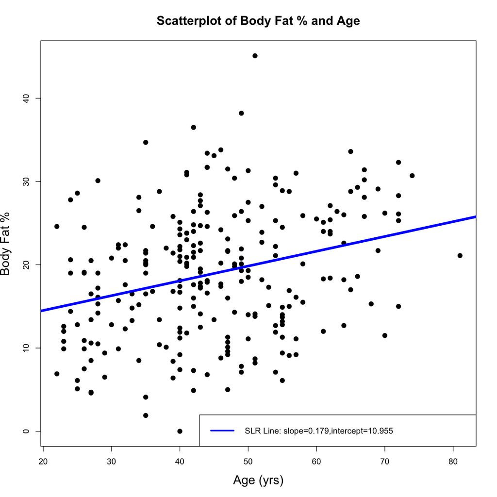

```r
plot(AGE,BODYFAT,pch=19,cex=1.2,cex.lab=1.5,cex.main=1.5,
     xlab="Age (yrs)",ylab="Body Fat %",main="Scatterplot of Body Fat % and Age")
lmmodel = lm(BODYFAT ~ AGE)
abline(lmmodel,col="blue",lwd=5) #lwd is the line weight and makes the line thicker.
legend("bottomright",c("SLR Line: slope=0.179,intercept=10.955"),col="blue",lwd=3,lty=c(1))
summary(lmmodel)
```

According to our SLR model, if we want to use age to predict body fat %, we can use the equation

$$ \text{Body Fat Pct} = 10.955 + 0.179 \text{Age} $$

For example, for a recent male college graduate (e.g. age 22), his predicted body fat % percentage would be around 14.87%. There is a 95% probability that his body fat is between 0.10% and 29.64%.

**Observation 1**: Age explains about 8.4% of the variation in body fat % (based on $R^2$)

**Observation 2**: Every year, men gain, on average, 0.179% of body fat %. Every decade, men gain, on average, 1.79% of body fat %.

```r
predict(lmmodel,newdata=data.frame(AGE=22),interval="predict")
```

A matrix: 1 × 3 of type dbl

|  | fit | lwr | upr |
| --- | --- | --- | --- |
| 1 | 14.86828 | 0.1012624 | 29.6353 |

### Testing Relationship Between Age and Body Fat

$$ \text{ Body Fat Pct } = 10.955 + 0.179 \text{Age} $$

Suppose the null hypothesis is that age is (linearly) unrelated to body fat %, i.e. $H_0: \beta_1 = 0$, and the alternative is that it isn't, i.e. $H_1: \beta_1 \neq 0$. The associated p-value is 3.04 * 10^-6.

We can declare that there is a linear relationship between age and body fat %. However, our conclusion carries a 5% error rate where we may have falsely declared that there is a relationship even though there truly isn't a relationship.

Correspondingly, the 95% confidence interval for the slope is $(0.10, 0.25)$ and the intercept is $(7.54, 14.37)$. In other words, we are 95% confident that the interval $(0.10, 0.25)$ contains the true slope value $\beta_1$.

```r
confint(lmmodel)
```

A matrix: 2 × 2 of type dbl

|  | 2.5 % | 97.5 % |
| --- | --- | --- |
| (Intercept) | 7.536883 | 14.374040 |
| AGE | 0.104517 | 0.251194 |

## Step 4: Diagnostics

After model fitting, I typically diagnose the SLR assumptions with a residual plot and a QQ plot.

1. Residual plot: good for diagnosing (i) linearity vioations, (ii) homoskedasticity violations, and (iii) detecting outliers in $Y$
2. QQ plot: good for diagnosing violations to Normality

Let's check linearity, homoskedasticity, and Normality.

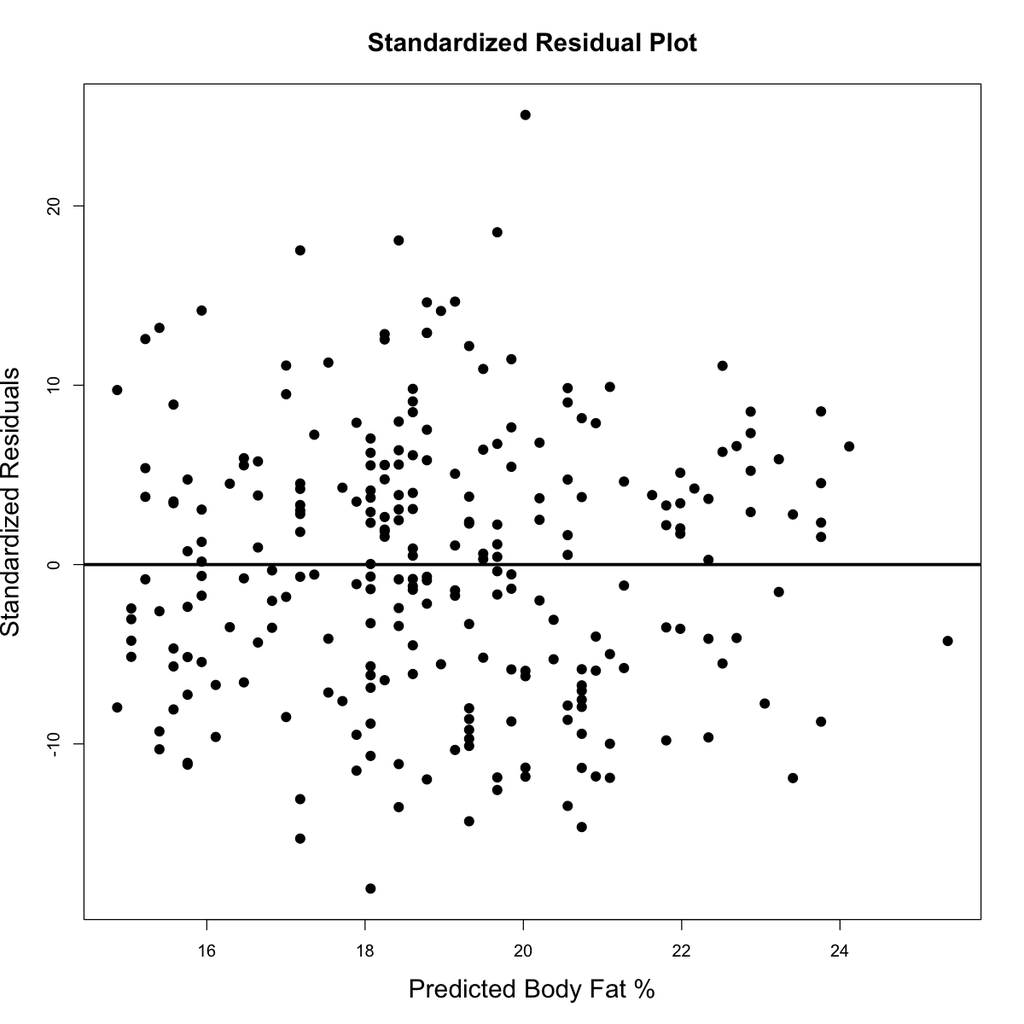

```r
par(mfrow = c(1,1))
plot(predict(lmmodel),resid(lmmodel),pch=19,cex=1.2,cex.lab=1.5,cex.main=1.5,
    xlab="Predicted Body Fat %", ylab="Standardized Residuals",main="Standardized Residual Plot")
abline(a=0,b=0,col="black",lwd=3)
```

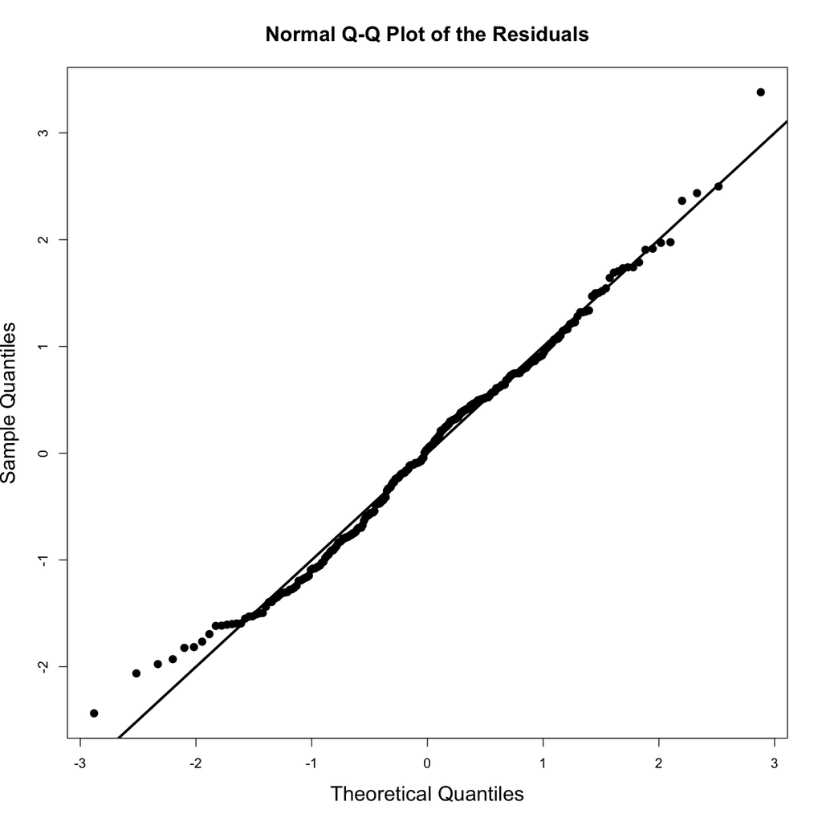

```r
qqnorm(rstandard(lmmodel),pch=19,cex=1.2,cex.lab=1.5,cex.main=1.5,
      main="Normal Q-Q Plot of the Residuals")
abline(a=0,b=1,col="black",lwd=3)
```

## Outliers in Y, Leverage and Influential Points

For outliers in $Y$, we can use the residual plot above.

From our model of body fat based on age, there also does not seem to be any outliers in $Y$ (this is subjective though...)

- You'll find that depending on the type of $X$ we use, there may be outliers in $Y$ or leverage/influential points may arise. For example, if we decided that our predictor was weight, then the aforementioned heavy man would probably be a leverage point (or an influential point) and some outliers in $Y$ may arise.

We should also check for leverage and influential points.

For leverage points, we'll use $p_{ii}$ measures from the lectures.

For influential points, we will use both the Cook's distance and the $p_{ii}$ measures.

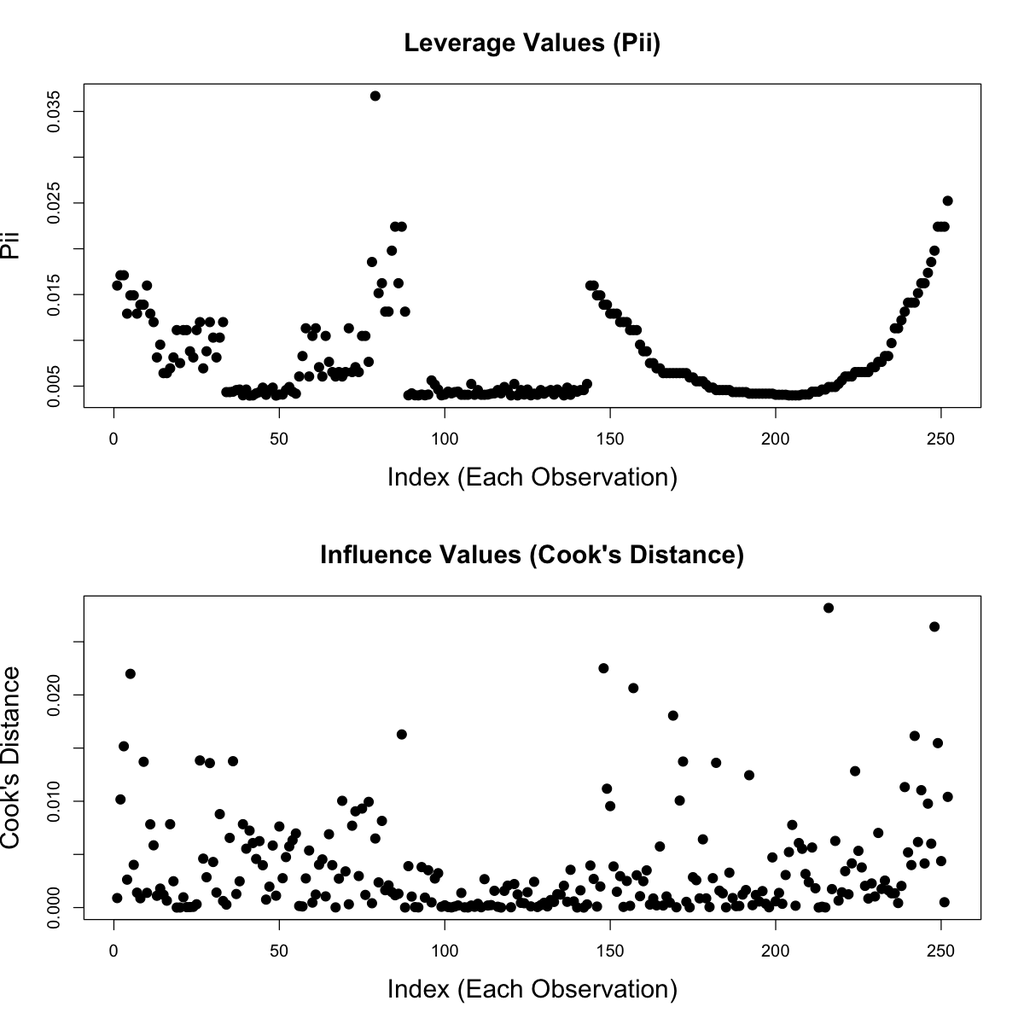

```r
pii = hatvalues(lmmodel)
cooki = cooks.distance(lmmodel)

par(mfrow = c(2,1))
n = dim(BodyFat)[1]
plot(1:n,pii,type="p",pch=19,cex=1.2,cex.lab=1.5,cex.main=1.5,
     xlab="Index (Each Observation)",ylab="Pii",main="Leverage Values (Pii)")
plot(1:n,cooki,type="p",pch=19,cex=1.2,cex.lab=1.5,cex.main=1.5,
     xlab="Index (Each Observation)",ylab="Cook's Distance",main="Influence Values (Cook's Distance)")
```

However, there does not seem to be any influential points by comparing both the Cook's distance and the leverage values.

Our Proposed SLR Model if we want to use age to predict body fat %:

$$ \text{ Body Fat Pct} = 10.955 + 0.179 \text{Age} $$

**Possible rule of thumb**: "multiply your age by 0.2 and add 11"

**Inference about Relationship**: There is clearly a linear relationship between age and body fat % and this relationship is significant at the $\alpha = 0.05$ level (with p-value $3.04*10^{-6}$). However, age only explains about 8.4% of all the variation in body fat %.

Also, according to this model, every year, a male is expected to gain about 0.18% in body fat %

**Strengths and Weakness of Model**: I think the SLR is a reasonable model between body fat % and age, despite some caveats.

Overall, our model provides a very simple way of guess-timating the body fat % purely based on age. However, because of its simplicity, our predictions aren't very accurate. In addition, when interpreting the linear model, we note that the constant effect assumption is likely vioalted. Other assumptions (linearity, homoskedasticity and Normality) seem plausible, but homoskedasticity and Normality may be slightly violated.